# Web APIs

Lecture 13

Dr. Colin Rundel

## URLs

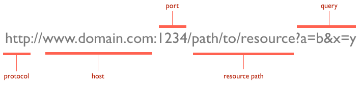

From [HTTP: The Protocol Every Web Developer Must Know](http://code.tutsplus.com/tutorials/http-the-protocol-every-web-developer-must-know-part-1--net-31177)

## Query Strings

Provides named parameter(s) and value(s) that modify the behavior of the resulting page.

Format generally follows:

`?arg1=value1&arg2=value2&arg3=value3`

Some quick examples,

- `http://lmgtfy.com/?q=hello%20world`
- `http://maps.googleapis.com/maps/api/geocode/json?sensor=false&address=1600+Amphitheatre+Parkway`
- `https://nomnom-prod-api.dennys.com/mapbox/geocoding/v5/mapbox.places/raleigh,%20nc.json?` `types=country,region,postcode,place&country=us,pr,vi,gu,mp,ca`

## URL encoding

This is will often be handled automatically by your web browser or other tool, but it is useful to know a bit about what is happening

- Spaces will encoded as ‘+’ or ‘%20’
- Certain characters are reserved and will be replaced with the percent-encoded version within a URL

| ! | # | $ | & | ’ | ( | ) |
| --- | --- | --- | --- | --- | --- | --- |
| %21 | %23 | %24 | %26 | %27 | %28 | %29 |
| * | + | , | / | : | ; | = |
| %2A | %2B | %2C | %2F | %3A | %3B | %3D |
| ? | @ | [ | ] |  |  |  |
| %3F | %40 | %5B | %5D |  |  |  |

- Characters that cannot be converted to the correct charset are replaced with HTML numeric character references (e.g. a Σ would be encoded as &#931; )

## Examples

```r
URLencode("http://lmgtfy.com/?q=hello world")
```

```
[1] "http://lmgtfy.com/?q=hello%20world"
```

```r
URLdecode("http://lmgtfy.com/?q=hello%20world")
```

```
[1] "http://lmgtfy.com/?q=hello world"
```

```r
URLencode("!#$&'()*+,/:;=?@[]")
```

```
[1] "!#$&'()*+,/:;=?@[]"
```

```r
URLencode("!#$&'()*+,/:;=?@[]", reserved = TRUE)
```

```
[1] "%21%23%24%26%27%28%29%2A%2B%2C%2F%3A%3B%3D%3F%40%5B%5D"
```

```r
URLencode("!#$&'()*+,/:;=?@[]", reserved = TRUE) |>
  URLdecode()
```

```
[1] "!#$&'()*+,/:;=?@[]"
```

```r
URLencode("Σ")
```

```
[1] "%CE%A3"
```

```r
URLdecode("%CE%A3")
```

```
[1] "Σ"
```

## Examples (httpuv)

```r
httpuv::encodeURI("http://lmgtfy.com/?q=hello world")
```

```
[1] "http://lmgtfy.com/?q=hello%20world"
```

```r
httpuv::decodeURI("http://lmgtfy.com/?q=hello%20world")
```

```
[1] "http://lmgtfy.com/?q=hello world"
```

```r
httpuv::encodeURI("!#$&'()*+,/:;=?@[]")
```

```
[1] "!%23$&'()*+,/:;=?@%5B%5D"
```

```r
httpuv::encodeURI("!#$&'()*+,/:;=?@[]") |>
  httpuv::decodeURI()
```

```
[1] "!#$&'()*+,/:;=?@[]"
```

```r
httpuv::encodeURIComponent("!#$&'()*+,/:;=?@[]")
```

```
[1] "!%23%24%26'()*%2B%2C%2F%3A%3B%3D%3F%40%5B%5D"
```

```r
httpuv::encodeURIComponent("!#$&'()*+,/:;=?@[]") |>
  httpuv::decodeURIComponent()
```

```
[1] "!#$&'()*+,/:;=?@[]"
```

```r
httpuv::encodeURI("Σ")
```

```
[1] "%CE%A3"
```

```r
httpuv::decodeURI("%CE%A3")
```

```
[1] "Σ"
```

# RESTful APIs

## REST

*RE*presentational *S*tate *T*ransfer

- describes an architectural style for web services (not a standard)
- all communication via HTTP requests
- Key features:
  - client–server architecture
  - addressible (specific URL endpoints)
  - stateless (no client information stored between requests)
  - layered / hierarchical
  - cacheability

## GitHub API

GitHub provides a REST API that allows you to interact with most of the data available on the website.

There is extensive documentation and a huge number of endpoints to use - almost anything that can be done on the website can also be done via the API.

[GitHub REST API](https://docs.github.com/en/rest)

# Demo 1 - GitHub API Basic access

[Get a user](https://docs.github.com/en/rest/users/users?apiVersion=2022-11-28#get-a-user)

[List organization repositories](https://docs.github.com/en/rest/repos/repos?apiVersion=2022-11-28#list-organization-repositories)

# httr2

## Background

`httr2` is a package designed around the construction and handling of HTTP requests and responses. It is a rewrite of the `httr` package and includes the following features:

- Pipeable API
- Explicit request object, with support for
  - rate limiting
  - retries
  - OAuth
  - Secrure secret storage
- Explicit response object, with support for
  - error codes / reporting
  - common body encoding (e.g. json, etc.)

## Structure of an HTTP Request

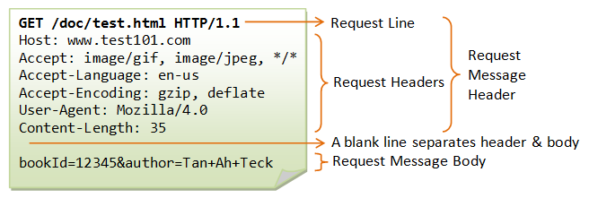

[Source](https://www3.ntu.edu.sg/home/ehchua/programming/webprogramming/http_basics.html)

## HTTP Methods / Verbs

- *GET* - fetch a resource
- *POST* - create a new resource
- *PUT* - full update of a resource
- *PATCH* - partial update of a resource
- *DELETE* - delete a resource.

Less common verbs: *HEAD*, *TRACE*, *OPTIONS*.

Based on [HTTP: The Protocol Every Web Developer Must Know](http://code.tutsplus.com/tutorials/http-the-protocol-every-web-developer-must-know-part-1--net-31177)

## httr2 request objects

A new request object is constructed via `request()` which is then modifed via `req_*()` functions

Some useful functions:

- `request()` - initialize a request object
- `req_method()` - set HTTP method
- `req_url_query()` - add query parameters to URL
- `req_url_*()` - add or modify URL
- `req_body_*()` - set body content (various formats and sources)
- `req_user_agent()` - set user-agent
- `req_dry_run()` - shows the exact request that will be made

## Structure of an HTTP Response

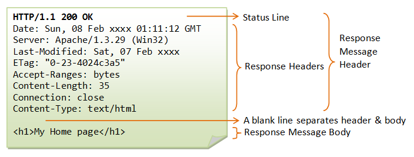

[Source](https://www3.ntu.edu.sg/home/ehchua/programming/webprogramming/http_basics.html)

## Status Codes

- 1xx: Informational Messages
- 2xx: Successful
- 3xx: Redirection
- 4xx: Client Error
- 5xx: Server Error

## httr2 response objects

Once constructed a request is made via `req_perform()` which returns a response object (the most recent response can also be retrieved via `last_response()`). Content of the response are accessed via the `resp_*()` functions

Some useful functions:

- `resp_status()` - extract HTTP status code
- `resp_status_desc()` - return a text description of the status code
- `resp_content_type()` - extract content type and encoding
- `resp_body_*()` - extract body from a specific format (`json`, `html`, `xml`, etc.)
- `resp_headers()` - extract response headers

# Demo 2 - httr2 + GitHub

Sta 523 - Fall 2024